# Tutorial linguagem R

# 1 INTRODUÇÃO

Esta página é um exercício para o aprendizado do uso básico e de algumas ferramentas estatísticas usuais do **R**. Simultaneamente pretendemos fazer algumas análises básicas de alguns dos dados públicos disponibilizados pelo *ICMBio*. O objetivo é aprender o básico através da função *?* de ajuda do *R*. A ajuda é apresentada ao digitar na linha de comando do console *? seguido do nome* da função, do pacote (ou biblioteca) de funções, como o exemplo a seguir:

```r
? sort
```

```
sort {base}
Sorting or Ordering Vectors
Description
Sort (or order) a vector or factor (partially) into ascending or descending order. For ordering along more than one variable, e.g., for sorting data frames, see order.

Usage
sort(x, decreasing = FALSE, ...)
(...)
```

Também é pssível obter ajuda sobre assuntos mais gerais utilizando a função *?? seguida do termo* que estamos pesquisando, por exemplo:

```r
?? Bayes
```

```
Help pages:
bayestestR::bayesfactor     Bayes Factors (BF)
bayestestR::bayesfactor_inclusion       Inclusion Bayes Factors for testing predictors across Bayesian models
bayestestR::bayesfactor_models      Bayes Factors (BF) for model comparison
bayestestR::bayesfactor_parameters      Bayes Factors (BF) for a Single Parameter
bayestestR::bayesfactor_restricted      Bayes Factors (BF) for Order Restricted Models
(...)
```

Sobretudo, pretendemos desenvolver o conteúdo através da adaptação de exemplos, obtidos com o comando `example()` do R que traz exemplos das funções disponíveis no R.

```r
example("sample")
```

```
sample> x <- 1:12

sample> # a random permutation
sample> sample(x)
 [1]  8  1  2  3  4 12  7  6  9  5 10 11

sample> # bootstrap resampling -- only if length(x) > 1 !
sample> sample(x, replace = TRUE)
 [1]  8 12  7 12  2  1  3  1 10  2  7  6
(...)
```

# 2 TIPOS

O R suporta muitos tipos de dados. Os *tipos* básicos e combinações destes são os seguintes:

Os tipos básicos servem de elementos para a construção dos tipos compostos.

| Tipo de Dados | Descrição | Exemplo |
| --- | --- | --- |
| Numérico | Representa números reais (com ou sem casas decimais) | `3,14, 10, -2,5` |
| Inteiro | Representa números inteiros (sem casas decimais). Acrescente L para especificar o tipo inteiro. | `10L, -5L, 0L` |
| Caractere | Representa texto ou sequências de caracteres, entre aspas simples ou duplas. | `"Olá", 'R', "123"` |
| Lógico | Representa valores booleanos, TRUE ou FALSE. | `TRUE, FALSE` |
| Complexo | Representa números complexos com partes reais e imaginárias. | `2 + 3i` |
| Raw | Representa bytes brutos de dados. | `as.raw(c(0x41, 0x42))` |

Com os tipos básicos é possível construído tipos mais complexos.

| TIPO | DESCRIÇÃO |
| --- | --- |
| Caractere | Representa valores de sequência alfabética. |
| Fator | Um tipo especial de sequência de caracteres, que podem possuir ordem. Exemplo: `factor(c(0,0,1,0,1,1,0),c(0,1),c("Verdadeiro","Falso"))` |
| Vetor | Pode ser numérico, caractere ou lógico. Por ex. `c(1,2,5.3,6,-2,4)` é um vetor numérico. |
| Matriz | Todas as colunas em uma matriz devem ter o mesmo modo e comprimento. Por ex. `matrix(c(11,12,21,22),2,2)`. |
| Data Frame | Mais geral do que uma matriz, pois colunas diferentes podem ter modos diferentes |
| Lista | Uma coleção ordenada de objetos, que pode ser uma variedade de objetos sob um nome |

Para determinar os tipos de dados, você pode usar as funções *class(), mode() ou typeof()*. A seguir utilizamos a função *cat()*, para imprimir, de maneira mais clara, os resultados da função *typeof()* aplicada sobre os diferentes *tipos* apresentados.

```r
 cat(" 3.1415 ->  ", typeof(3.1415), "\n")
```

```
 3.1415 ->   double
```

```r
 cat(" pi ->  ", typeof(pi), "\n")
```

```
 pi ->   double
```

```r
 cat(" 3 ->  ", typeof(3), "\n")
```

```
 3 ->   double
```

```r
 cat(" 3L ->  ", typeof(3L), "\n")
```

```
 3L ->   integer
```

```r
 cat(" '3.1415' -> ", typeof("3.1415"), "\n")
```

```
 '3.1415' ->  character
```

```r
 cat(" TRUE ->  ", typeof(TRUE), "\n")
```

```
 TRUE ->   logical
```

```r
 cat(" 2 + 3i ->  ", typeof(2 + 3i), "\n")
```

```
 2 + 3i ->   complex
```

```r
 cat(" as.raw(c(0x41, 0x42)) ->  ", typeof(as.raw(c(0x41, 0x42))), "\n")
```

```
 as.raw(c(0x41, 0x42)) ->   raw
```

# 3 CONSTANTES

Existem algumas constantes predefinidas como tipos especiais no *R*:

| CONSTANTE | DEFINIÇÃO |
| --- | --- |
| pi | pi (π) é uma constante matemática que representa a relação entre o comprimento de uma circunferência e o seu diâmetro. |
| Inf | Inf e -Inf são infinito positivo e negativo. |
| NaN | *Not a Number* ou o mesmo que uma indefinição. Não confundir com N.A. |
| N.A. | *Not Available*”* no *R* significa “Não Disponível”, referindo-se a um elemento faltante em um conjunto. |

Estes valores podem aparecer em algumas situações (que não foram bem definida aqui) mas que servem de ilustração para o funcionamento do funcionamento na linguagem *R*:

| FORMULA | CÓDIGO R | RESULTADO | TIPO DO RESULTADO |
| --- | --- | --- | --- |
| $0/0$ | `0/0` | $NaN$ | double |
| $0/\pi$ | `0/pi` | $0$ | double |
| $0/\infty$ | `0/Inf` | $0$ | double |
| $\pi/0$ | `pi/0` | $Inf$ | double |
| $\pi/\pi$ | `pi/pi` | $1$ | double |
| $\pi/\infty$ | `pi/Inf` | $0$ | double |
| $\infty/0$ | `Inf/0` | $Inf$ | double |
| $\infty/\pi$ | `Inf/pi` | $Inf$ | double |
| $\infty/\infty$ | `Inf/Inf` | $NaN$ | double |
| $\infty-\infty$ | `Inf-Inf` | $NaN$ | double |

Importante ter em mente que a implementação do *R* optou por esta forma para manter a consistencia da maior parte dos algoritmos utilizados na implementação da linguagem, não visando uma coerência com qualquer fundamentação matemática ou teoria estatística.

# 4 OPERAÇÕES BÁSICA

## 4.1 Aritméticas e lógicas

| Operador | Descrição | Exemplo | Código |
| --- | --- | --- | --- |
| + | Operador de adição | $3 + 5$ | `3+5` |
| - | Operador de subtração | $3 - 5$ | `3-5` |
| * | Operador de multiplicação | $3 * 5$ | `3*5` |
| / | Operador de divisão | $3 / 5$ | `3/5` |
| : | Operador de sequência | $3 : 5$ | `3:5` |
| ^ | Operador exponencial | $3 ^ 5$ | `3^5` |
| %% | Operador de módulo | $3 %% 5$ | `3%%5` |
| == | Operador de igualdade | $3 == 5$ | `3==5` |
| > | Operador “maior que” | $3 > 5$ | `3>5` |
| < | Operador “menor que” | $3 < 5$ | `3<5` |
| <= | Operador “menor ou igual” | $3 <= 5$ | `3<=5` |
| ! | Operador “Não” | $3 ! 5$ | `3!5` |
| & | Operador lógico “E” | $3 & 5$ | `3&5` |
| \| | Operador lógico “OU” | $3 + 5$ | `3\|5` |

A seguir apresentaremos exemplos de uso de operadores, para tal utilizaremos o comando `print()`:

```r
print(3+5)
print(3-5)
print(3*5)
print(3/5)
print(3:5)
print(3^5)
print(3%%5)
print(3==5)
print(3>5)
print(3<5)
print(3<=5)
print(3>=5)
print(!TRUE)
print(TRUE&FALSE)
print(TRUE|FALSE)
```

[output not shown]

Ou ainda:

```r
3 != 5
```

```
[1] TRUE
```

```r
3 < 5
```

```
[1] TRUE
```

```r
3 == 5
```

```
[1] FALSE
```

```r
3 > 5
```

```
[1] FALSE
```

```r
3*FALSE / 5*TRUE
```

```
[1] 0
```

```r
5 + NA
```

```
[1] NA
```

```r
TRUE&FALSE
```

```
[1] FALSE
```

```r
TRUE|FALSE
```

```
[1] TRUE
```

```r
TRUE == T
```

```
[1] TRUE
```

```r
TRUE + TRUE
```

```
[1] 2
```

# 5 VARIÁVEIS

No *R*, uma variável é como um contêiner que contém um valor. Você pode pensar nisso como um local de armazenamento nomeado na memória do computador. Esses valores podem ser de diferentes tipos, como números, texto ou valores lógicos (*TRUE/FALSE*). Variáveis permitem que você armazene, manipule e reutilize dados dentro de seus programas R.

## 5.1 5.1 - Criando variáveis

Usando o Operador de atribuição para a esquerda (**<-**) :

```r
MinhaVariavel <- 10
MinhaVariavelTexto <- "Bem vind@ ao R!"
MinhaVariavelLogica <- TRUE
```

```r
MinhaVariavel <- 10
MinhaVariavelTexto <- "Bem vind@ ao R!"
MinhaVariavelLogica <- TRUE
```

Embora o sinal de igual possa ser usado para atribuição, ele geralmente não é recomendado em R porque às vezes pode causar confusão em certos contextos.

Usando o Operador de igualdade (**=**) :

```r
MinhaVariavel = 10  # Pode causar confusão em algumas situações
```

## 5.2 5.2 - Automatizando a criação de variáveis

Criando variáveis em loop:

```r
nomes <- c("nomes","var_name")
for (i in 1:3) {
  var_name <- paste0("variable_", i) # Cria nomes de variáveis como "variable_1", "variable_2", etc.
  assign(var_name, i * 10) # Atribui valores a essas variáveis criadas dinamicamente
  nomes<-append(nomes,var_name)
}
print(nomes)
```

```
[1] "nomes"      "var_name"   "variable_1" "variable_2" "variable_3"
```

Criando variáveis via entrada do Usuário:

```r
user_input <- readline("Digite um nome de variável: ")
assign(user_input, 100)
```

Exemplo de aplicação para a criação de variáveis:

```r
# Crie uma variável para armazenar o raio de um círculo
radius <- as.integer(readline("Digite o tamanho do raio: "))
print(radius)
# Calcule a área do círculo
if(is.numeric(radius)){
  area <- pi * radius^2
  cat("A área do círculo de raio =",radius," é igual a ",area)
}
```

## 5.3 5.3 - Listando variáveis

As funções *ls()* e *objects()* retornam um vetor de cadeias de caracteres fornecendo os nomes dos objetos e variáveis no ambiente especificado.

Usando o *ls()*:

```r
ls()
```

## 5.4 5.4 - Eliminando variáveis

As funções *remove()* e *rm()* podem ser usados para remover objetos. Eles podem ser especificados sucessivamente como *strings*, *listas*, *vetores* de caracteres, ou por meio de uma combinação de ambos. Todos os objetos assim especificados serão removidos.

Eliminando variáveis com a função *rm()*:

```r
rm(nomes)
rm("nomes")
```

Com o comando `rm(list = ls())` é possível remover praticamente todas as variáveis do ambiente, portanto, **use com cuidado !!**.

# 6 VETORES

## 6.1 Criação de vetores

Criando um vetor com nomes e exibindo-os:

```r
nomes<-c("Mafalda", "Papá", "Mamã", "Filipe", "Manolito", "Susanita", "Guille", "Miguel", "Liberdade", "Burocracia")
print(nomes)
```

```
 [1] "Mafalda"    "Papá"       "Mamã"       "Filipe"     "Manolito"   "Susanita"   "Guille"
 [8] "Miguel"     "Liberdade"  "Burocracia"
```

Mostrando do quarto ao sétimo nome:

```r
print(nomes[4:7])
```

```
[1] "Filipe"   "Manolito" "Susanita" "Guille"
```

Mostrando todos on nomes menos o sexto:

```r
print(nomes[-6])
```

```
[1] "Mafalda"    "Papá"       "Mamã"       "Filipe"     "Manolito"   "Guille"     "Miguel"
[8] "Liberdade"  "Burocracia"
```

Mostrando em ordem reversa:

```r
print(nomes[9:1])
```

```
[1] "Liberdade" "Miguel"    "Guille"    "Susanita"  "Manolito"  "Filipe"
[7] "Mamã"      "Papá"      "Mafalda"
```

## 6.2 Operando com vetores

Calculando o valor de $\pi$:

```r
a<-c(1:1000)
print(a[1:5])
```

```
[1] 1 2 3 4 5
```

```r
b<- 1 / (a^4)
print(b[1:5])
```

```
[1] 1.00000000 0.06250000 0.01234568 0.00390625 0.00160000
```

```r
meu_pi<-sqrt(sqrt(90*sum(b)))
print(meu_pi)
```

```
[1] 3.141593
```

Comparações com e entre vetores:

```r
print(b[1:5]>0.01)
```

```
[1]  TRUE  TRUE  TRUE FALSE FALSE
```

```r
print(a[1:5]==b[1:5])
```

```
[1]  TRUE FALSE FALSE FALSE FALSE
```

Usando a mesma lágica podemos selecionar elementos pela condição:

```r
print(a[a<=5])
```

```
[1] 1 2 3 4 5
```

```r
b[which(b >= 0.01)]
```

```
[1] 1.00000000 0.06250000 0.01234568
```

# 7 FUNÇÕES

## 7.1 Funções Matemáticas

Funções matemáticas predefinidas mais usuais:

[output not shown]

## 7.2 Funções Estatísticas

Funções estatísticas predefinidas mais usuais:

| Função | Descrição | Exemplo |
| --- | --- | --- |
| mean(x) | Média aritmética de x | mean(c(1, 2, 3, 4, 5)) results in 3 |
| median(x) | Mediana de x | median(c(1, 2, 3, 4, 5)) = 3 |
| sd(x) | Desvio padrão de x | sd(c(1, 2, 3, 4, 5)) = 1.581139 |
| var(x) | Variância de x | var(c(1, 2, 3, 4, 5)) = 2.5 |
| quantile(x, probs) | Quantis de x em probabilidades especificadas | quantile(x, probs = c(0.25, 0.75)) gives the 25th and 75th percentiles |
| range(x) | Valores mínimo e máximo de x | range(c(1, 5, 2, 4, 3)) = 1 5 |
| IQR(x) | Intervalo interquartil de x | IQR(c(1, 2, 3, 4, 5)) = 2 |
| summary(x) | Estatísticas resumidas de x (mín., 1º quantil, mediana, média, 3º quantil, máx.) | summary(c(1, 2, 3, 4, 5)) |
| cor(x, y) | Coeficiente de correlação entre x e y | cor(x, y) = 0.3 |
| cov(x, y) | Covariância entre x e y | cov(x, y) = 0.75 |
| lm(y ~ x) | Regressão linear de y em x | model <- lm(y ~ x) |
| t.test(x, y) | teste t para comparar médias de x e y | t.test(x, y) |
| wilcox.test(x, y) | Teste de soma de postos de Wilcoxon (não paramétrico) | wilcox.test(x, y) |
| chisq.test(x) | Teste qui-quadrado para qualidade de ajuste ou independência | chisq.test(x) |
| aov(y ~ x) | Análise de variância (ANOVA) | model <- aov(y ~ x) |

## 7.3 Funções para manipulação de strings

Funções para manipulação de *strings* ou vetores de caractéres (char)

| Função | Descrição | Exemplo |
| --- | --- | --- |
| nchar(x) | Número de caracteres em uma string | nchar(“Hello”) results in 5 |
| paste(…, sep = ” “) | Concatena strings | paste(“Hello”, “world”) = “Hello world” |
| substr(x, start, stop) | Extrai substring | substr(“Hello”, 2, 4) = “ell” |
| strsplit(x, split) | Divide string por delimitador | strsplit(“Hello world”, ” “) = a list with elements”Hello” and “world” |
| grep(pattern, x) | Encontra padrão em string | grep(“ell”, “Hello”) = 1 (index of match) |
| gsub(pattern, replacement, x) | Substitui padrão por outra string | gsub(“o”, “a”, “Hello”) = “Hella” |
| tolower(x) | Converte para minúsculas | tolower(“Hello”) = “hello” |
| toupper(x) | Converte para maiúsculas | toupper(“Hello”) = “HELLO” |
| trimws(x) | Remove espaços em branco iniciais/finais | trimws(” Hello “) =”Hello” |
| cat(x) | Concatena e imprime as strings em x | cat(“Olá,”, “como vai?”) = “Olá, como vai?” |

## 7.4 Funções para manipulação de vetores

| Função | Descrição | Exemplo |
| --- | --- | --- |
| paste(…) | Concatena strings, com um separador | paste(“Hello”, “world”, sep = “-”) = “Hello-world” |
| paste0(…) | Concatena strings, sem um separador | paste0(“Hello”, “world”) = “Helloworld” |
| order(x) | Retorna uma permutação de índices que classificaria x | order(c(3, 1, 2)) = 2 3 1 |
| length(x) | Retorna o comprimento de um objeto (vetor, lista, matriz, etc.) | length(c(1, 2, 3)) = 3 |
| names(x) | Obtém ou define os nomes dos elementos em um objeto (lista, vetor, etc.) | names(my_list) <- c(“a”, “b”, “c”) |
| cumsum(x) | Retorna a soma cumulativa de um vetor numérico | cumsum(c(1, 2, 3)) = 1 3 6 |
| cumprod(x) | Retorna o produto cumulativo de um vetor numérico | cumprod(c(1, 2, 3)) = 1 2 6 |
| cummin(x) | Retorna o mínimo cumulativo de um vetor numérico | cummin(c(3, 1, 2, 4)) = 3 1 1 1 |
| cummax(x) | Retorna o máximo cumulativo de um vetor numérico | cummax(c(3, 1, 2, 4)) = 3 3 3 4 |
| sort(x) | Classifica um vetor (ou as colunas de uma matriz) em ordem crescente | sort(c(3, 1, 2)) = 1 2 3 |
| rev(x) | Inverte a ordem dos elementos em um vetor | rev(c(1, 2, 3)) = 3 2 1 |
| is.na(x) | Retorna um vetor lógico indicando se os elementos estão faltando (NA) | is.na(c(1, NA, 3)) = FALSE TRUE FALSE |
| is.null(x) | Retorna TRUE se x for NULL, FALSE caso contrário | is.null(NULL) = TRUE |

## 7.5 Outras funções para manipulação de vetores

| Função | Descrição | Exemplo |
| --- | --- | --- |
| c(…) | Combinar elementos em um vetor | c(1, 2, 3) creates a vector 1 2 3 |
| length(x) | Comprimento de um vetor | length(c(1, 2, 3)) = 3 |
| sort(x) | Classificar um vetor | sort(c(3, 1, 2)) = 1 2 3 |
| rev(x) | Reverter um vetor | rev(c(1, 2, 3)) = 3 2 1 |
| unique(x) | Extrair elementos únicos | unique(c(1, 2, 2, 3)) = 1 2 3 |
| append(x, values) | Adicionar valores a um vetor | append(c(1, 2), 3) = 1 2 3 |
| rep(x, times) | Repetir um vetor | rep(1:2, times = 3) = 1 2 1 2 1 2 |
| which(x) | Retorna os índices correspondentes aos valores verdadeiros | which(c(T,F,T,F,T)) = 1 3 5 |

## 7.6 Funções para manipular matrizes

| Função | Descrição |  |
| --- | --- | --- |
| t() | Retorna a matriz transposta |  |
| diag(k) | Cria uma matriz identidade k x k |  |
| det() | Calcula o determinante da matriz |  |
| diag() | Retorna os elementos da diagonal principal |  |
| dim() | Retorna a dimensão da matriz |  |
| ncol | Retorna o número de colunas da matriz |  |
| nrow() | Retorna o número de linhas da matriz |  |
| rowSums() | Retorna a soma das linhas da matriz |  |
| rowMeans() | Retorna a média das linhas das matriz |  |
| colSums() | Retorna a soma das colunas da matriz |  |
| colMeans() | Retorna a média das colunas da matriz |  |

# 8 MATRIZES

A função *matrix()* cria uma matriz a partir do conjunto de valores fornecido. A função *as.matrix()* tenta transformar seu argumento em uma matriz, e *is.matrix()* testa se seu argumento é uma matriz (estrita). A indexação dos elementos dentro das matrizes é sempre o mesmo: $\begin{pmatrix}a_{1,1} & & \\ & \ddots & \\ & & a_{m,n}\end{pmatrix}$

## 8.1 Criando matrizes

Criando uma matriz 3x3 com os valores de 1 a 9:

```r
M1 <- matrix(
            seq(1, 9),
            ncol = 3,
            nrow = 3)
print(M1)
```

```
     [,1] [,2] [,3]
[1,]    1    4    7
[2,]    2    5    8
[3,]    3    6    9
```

Os valores são preenchidos da de cima para baixo, começando pela primeira coluna, seguindo praa as próximas colunas da esquerda para a direita, até a última coluna.

Criando uma matriz 3x3 com os valores de 1 a 9:

```r
M1 <- matrix(
            seq(1, 9),
            ncol = 3,
            nrow = 3,
            byrow = TRUE)
print(M1)
```

```
     [,1] [,2] [,3]
[1,]    1    2    3
[2,]    4    5    6
[3,]    7    8    9
```

Criando uma matriz 3x3 com os valores 1 a 9 aleatóriamente selecionados:

```r
M1 <- matrix(
            sample(seq(1, 9),9),
            ncol = 3,
            nrow = 3)
print(M1)
```

```
     [,1] [,2] [,3]
[1,]    6    2    1
[2,]    7    4    3
[3,]    8    9    5
```

```r
M1 <- matrix(
            sample(c(T,F), 5*3, replace = T),
            ncol = 5,
            nrow = 3)
print(M1)
```

```
      [,1] [,2]  [,3]  [,4]  [,5]
[1,]  TRUE TRUE FALSE  TRUE FALSE
[2,]  TRUE TRUE FALSE FALSE  TRUE
[3,] FALSE TRUE  TRUE  TRUE  TRUE
```

```r
set.seed(13) # fixa a sequência de valores aleatórios gerados
M1 <- matrix(
            sample(c("Cara", "Coroa"), 10, replace = TRUE),
            ncol = 10, nrow = 1)
set.seed(13)
M2 <- matrix(
            sample(c("Cara", "Coroa"), 10, replace = TRUE),
            ncol = 10, nrow = 1)
print(M1)
```

```
     [,1]    [,2]   [,3]    [,4]   [,5]    [,6]   [,7]    [,8]    [,9]    [,10]
[1,] "Coroa" "Cara" "Coroa" "Cara" "Coroa" "Cara" "Coroa" "Coroa" "Coroa" "Coroa"
```

```r
print(M2)
```

```
     [,1]    [,2]   [,3]    [,4]   [,5]    [,6]   [,7]    [,8]    [,9]    [,10]
[1,] "Coroa" "Cara" "Coroa" "Cara" "Coroa" "Cara" "Coroa" "Coroa" "Coroa" "Coroa"
```

## 8.2 Operações com matrizes

```r
M1<-matrix(c(1,0,0,1),2,2)
M2<-matrix(c(1:4),2,2,byrow = T)
cat("M1")
```

```
M1
```

```r
print(M1)
```

```
     [,1] [,2]
[1,]    1    0
[2,]    0    1
```

```r
cat("\n")
```

```r
cat("M2")
```

```
M2
```

```r
print(M2)
```

```
     [,1] [,2]
[1,]    1    2
[2,]    3    4
```

```r
cat("\n")
```

```r
cat("M1+M2")
```

```
M1+M2
```

```r
print(M1+M2)
```

```
     [,1] [,2]
[1,]    2    2
[2,]    3    5
```

```r
cat("\n")
```

```r
cat("M2-M1")
```

```
M2-M1
```

```r
print(M2-M1)
```

```
     [,1] [,2]
[1,]    0    2
[2,]    3    3
```

```r
cat("\n")
```

```r
cat("M1.M2")
```

```
M1.M2
```

```r
print(M1%*%M2)
```

```
     [,1] [,2]
[1,]    1    2
[2,]    3    4
```

```r
cat("\n")
```

```r
cat("M2.M1")
```

```
M2.M1
```

```r
print(M2%*%M1)
```

```
     [,1] [,2]
[1,]    1    2
[2,]    3    4
```

```r
cat("\n")
```

```r
cat("M1*M2")
```

```
M1*M2
```

```r
print(M1*M2)
```

```
     [,1] [,2]
[1,]    1    0
[2,]    0    4
```

```r
cat("\n")
```

```r
cat("M1/M2")
```

```
M1/M2
```

```r
print(M1/M2)
```

```
     [,1] [,2]
[1,]    1 0.00
[2,]    0 0.25
```

```r
cat("\n")
```

```r
cat("M2/M1")
```

```
M2/M1
```

```r
print(M2/M1)
```

```
     [,1] [,2]
[1,]    1  Inf
[2,]  Inf    4
```

```r
M1<-matrix(c(1,4,2,5,3,6),2,3)
M2<-matrix(c(1:4),2,2,byrow = T)
cat("M1")
```

```
M1
```

```r
print(M1)
```

```
     [,1] [,2] [,3]
[1,]    1    2    3
[2,]    4    5    6
```

```r
cat("\n")
```

```r
cat("M2")
```

```
M2
```

```r
print(M2)
```

```
     [,1] [,2]
[1,]    1    2
[2,]    3    4
```

```r
cat("\n")
```

```r
cat("M2.M1")
```

```
M2.M1
```

```r
print(M2%*%M1)
```

```
     [,1] [,2] [,3]
[1,]    9   12   15
[2,]   19   26   33
```

## 8.3 Selecionando partes de uma matriz

```r
cat("só colunas 1 e 5 : M1[,-c(2:4)]")
```

```
só colunas 1 e 5 : M1[,-c(2:4)]
```

```r
print(M1[,-c(2:4)])
```

[output not shown]

## 8.4 Nomeando linhas e colunas

```r
colnames(M1)<-c("Abobora","Banana","Cereja","Damasco","Ervilha")
rownames(M1)<-c("Arara","Barata","Canário","Dromedário","Elefante")
print(M1)
```

[output not shown]

```r
cat("\n")
```

```r
cat("Cerejas comidas :")
```

```
Cerejas comidas :
```

```r
cat("\n")
```

```r
print(M1[,"Cereja"])
```

```
     Arara     Barata    Canário Dromedário   Elefante
         3          8         13         18         23
```

```r
cat("\n")
```

```r
cat("Canário comeu :")
```

```
Canário comeu :
```

```r
cat("\n")
```

```r
print(M1["Canário",])
```

```
Abobora  Banana  Cereja Damasco Ervilha
     11      12      13      14      15
```

```r
cat("\n")
```

```r
cat("Barata e Canário comeram Bananas e Cerejas")
```

```
Barata e Canário comeram Bananas e Cerejas
```

```r
cat("\n")
```

```r
print(M1[c("Barata","Canário"),c("Banana","Cereja")])
```

```
        Banana Cereja
Barata       7      8
Canário     12     13
```

```r
cat("\n")
```

```r
cat("Canário comeu Cereja")
```

```
Canário comeu Cereja
```

```r
print(M1["Canário","Cereja"])
```

```
[1] 13
```

```r
cat("\n")
```

# 9 DADOS EXTERNOS

Nesta seção estudamos algumas maneiras de carregar dados externos. A referência para o estudo é o tutorial [Entrada e saída de dados](https://rawgit.com/lhmet/adar-ufsm/master/6_EntradaDeDados.html#salvando-e-carregando-objetos-em-arquivos-.rdata) do curso [FSC1104-Análise de dados ambientais com R](https://github.com/lhmet/adar-ufsm/tree/master).

A seguir apresentaremos alguns procedimentos para carregamento e salvamento de dados externos.

## 9.1 Carregando dados de tabelas *.csv*

Carregando a tabela de dados de autos de infração emitidos pelo ICMBio.

```r
autos_infracao_icmbio <- read_csv("~/BaseGeo/0_ICMBio/autos_infracao_icmbio.csv")
```

Visualizando as primeiras linhas do dado:

```r
head(autos_infracao_icmbio[, 1:10])
```

| FID | ogc_fid | vw_num_aut | numero_ai | serie | origem | tipo | valor_mult | embargo | apreensao |
| --- | --- | --- | --- | --- | --- | --- | --- | --- | --- |
| autos_infracao_icmbio.1 | 1 | 1 | 004TY6C1 | NA | Eletrônico | Multa Simples | 33150 | Sim | Não |
| autos_infracao_icmbio.2 | 2 | 2 | 009Z5YHU | NA | Eletrônico | Multa Simples | 500 | Não | Não |
| autos_infracao_icmbio.3 | 3 | 3 | 00EZFFO7 | NA | Eletrônico | Multa Simples | 28000 | Não | Não |
| autos_infracao_icmbio.4 | 4 | 4 | 00GXXMSY | NA | Eletrônico | Multa Simples | 445000 | Sim | Não |
| autos_infracao_icmbio.5 | 5 | 5 | 00UYJ7IF | NA | Eletrônico | Multa Simples | 3520 | Não | Não |
| autos_infracao_icmbio.6 | 6 | 6 | 00YAPNVR | NA | Eletrônico | Multa Simples | 80000 | Não | Não |

## 9.2 Rápida inspeção dos dados

Sumarizando:

```r
summary(autos_infracao_icmbio)
```

```
     FID               ogc_fid        vw_num_aut     numero_ai            serie
 Length:35837       Min.   :    1   Min.   :    1   Length:35837       Length:35837
 Class :character   1st Qu.: 8960   1st Qu.: 8960   Class :character   Class :character
 Mode  :character   Median :17919   Median :18621   Mode  :character   Mode  :character
                    Mean   :17919   Mean   :18409
                    3rd Qu.:26878   3rd Qu.:27580
                    Max.   :35837   Max.   :36539

    origem              tipo             valor_mult         embargo
 Length:35837       Length:35837       Min.   :       0   Length:35837
 Class :character   Class :character   1st Qu.:    1010   Class :character
 Mode  :character   Mode  :character   Median :    5000   Mode  :character
                                       Mean   :  154896
                                       3rd Qu.:   20000
                                       Max.   :86385000

  apreensao           autuado            cpf_cnpj           desc_ai
 Length:35837       Length:35837       Length:35837       Length:35837
 Class :character   Class :character   Class :character   Class :character
 Mode  :character   Mode  :character   Mode  :character   Mode  :character




  desc_sanc              data                 ano          artigo_1        artigo_2
 Length:35837       Min.   :215-11-11    Min.   : 215   Min.   : 0.00   Min.   :  0.0
 Class :character   1st Qu.:2013-03-23   1st Qu.:2013   1st Qu.:35.00   1st Qu.:  0.0
 Mode  :character   Median :2017-07-06   Median :2017   Median :50.00   Median : 93.0
                    Mean   :2017-04-05   Mean   :2017   Mean   :58.55   Mean   : 55.4
                    3rd Qu.:2021-06-10   3rd Qu.:2021   3rd Qu.:90.00   3rd Qu.: 93.0
                    Max.   :2024-09-02   Max.   :2024   Max.   :93.00   Max.   :225.0
                    NA's   :33           NA's   :33                     NA's   :6052
  tipo_infra          nome_uc              cnuc            municipio
 Length:35837       Length:35837       Length:35837       Length:35837
 Class :character   Class :character   Class :character   Class :character
 Mode  :character   Mode  :character   Mode  :character   Mode  :character




      uf             termos_emb         termos_apr         ordem_fisc
 Length:35837       Length:35837       Length:35837       Length:35837
 Class :character   Class :character   Class :character   Class :character
 Mode  :character   Mode  :character   Mode  :character   Mode  :character




   processo          julgamento          the_geom
 Length:35837       Length:35837       Length:35837
 Class :character   Class :character   Class :character
 Mode  :character   Mode  :character   Mode  :character
```

Sumario mais completo:

```r
#library(skimr)
skim(autos_infracao_icmbio)
```

```
── Data Summary ────────────────────────
                           Values
Name                       autos_infracao_icmbio
Number of rows             35837
Number of columns          29
_______________________
Column type frequency:
  character                22
  Date                     1
  numeric                  6
________________________
Group variables            None
```

|  | skim_variable | n_missing | complete_rate | min | max | empty | n_unique | whitespace |
| --- | --- | --- | --- | --- | --- | --- | --- | --- |
| 1 | FID | 0 | 1.00000000 | 23 | 27 | 0 | 35837 | 0 |
| 2 | numero_ai | 0 | 1.00000000 | 6 | 8 | 0 | 31744 | 0 |
| 3 | serie | 10801 | 0.69860758 | 1 | 1 | 0 | 2 | 0 |
| 4 | origem | 0 | 1.00000000 | 5 | 10 | 0 | 2 | 0 |
| 5 | tipo | 0 | 1.00000000 | 7 | 46 | 0 | 40 | 0 |
| 6 | embargo | 0 | 1.00000000 | 3 | 3 | 0 | 2 | 0 |
| 7 | apreensao | 0 | 1.00000000 | 3 | 3 | 0 | 2 | 0 |
| 8 | autuado | 1 | 0.99997210 | 1 | 86 | 0 | 27726 | 0 |
| 9 | cpf_cnpj | 4561 | 0.87272930 | 1 | 16 | 0 | 24509 | 0 |
| 10 | desc_ai | 194 | 0.99458660 | 1 | 254 | 0 | 31617 | 0 |

[output cut: 12 more lines]

|  | skim_variable | n_missing | complete_rate | min | max | median | n_unique |
| --- | --- | --- | --- | --- | --- | --- | --- |
| 1 | data | 33 | 0.9990792 | 215-11-11 | 2024-09-02 | 2017-07-06 | 5104 |

|  | skim_variable | n_missing | complete_rate | mean | sd | p0 | p25 | p50 | p75 | p100 | hist |
| --- | --- | --- | --- | --- | --- | --- | --- | --- | --- | --- | --- |
| 1 | ogc_fid | 0 | 1.0000000 | 17919.00000 | 1.034540e+04 | 1 | 8960 | 17919 | 26878 | 35837 | ▇▇▇▇▇ |
| 2 | vw_num_aut | 0 | 1.0000000 | 18409.42252 | 1.060321e+04 | 1 | 8960 | 18621 | 27580 | 36539 | ▇▇▇▇▇ |
| 3 | valor_mult | 0 | 1.0000000 | 154895.89401 | 1.346058e+06 | 0 | 1010 | 5000 | 20000 | 86385000 | ▇▁▁▁▁ |
| 4 | ano | 33 | 0.9990792 | 2016.73293 | 1.055231e+01 | 215 | 2013 | 2017 | 2021 | 2024 | ▁▁▁▁▇ |
| 5 | artigo_1 | 0 | 1.0000000 | 58.55465 | 2.381217e+01 | 0 | 35 | 50 | 90 | 93 | ▁▇▇▃▇ |
| 6 | artigo_2 | 6052 | 0.8311243 | 55.39537 | 4.565846e+01 | 0 | 0 | 93 | 93 | 225 | ▆▁▇▁▁ |

## 9.3 Rapida avaliação dos dados

Vamos, a título de exemplo, nos consentrar apenas nos dados de valores das multas.

Histograma dos valores dos autos de infração com valores **menores** do que R$ 10.000,00:

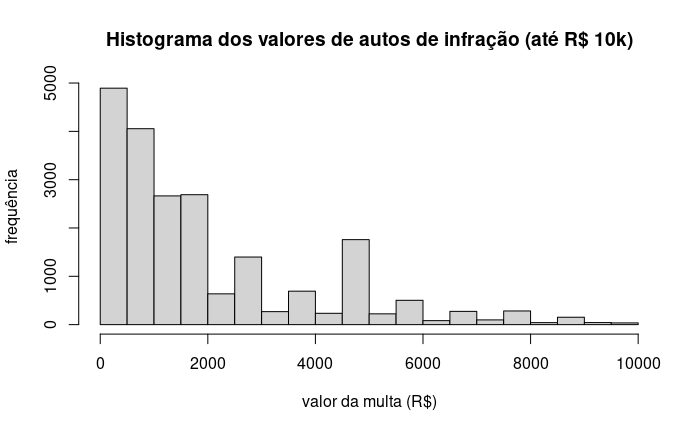

Bigode (diagrama de caixa) dos valores dos autos de infração com valores **menores** do que R$ 10.000,00:

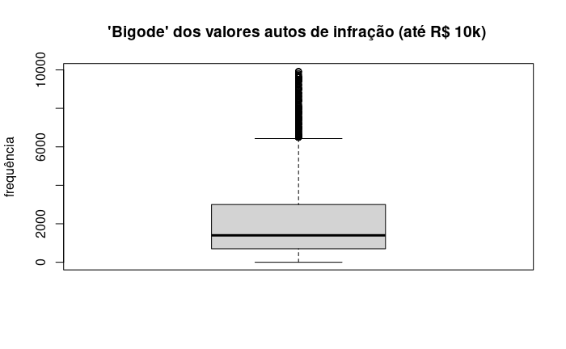

Histograma dos valores dos autos de infração com valores **entre** R$ 10.000,00 e 100.000,00:

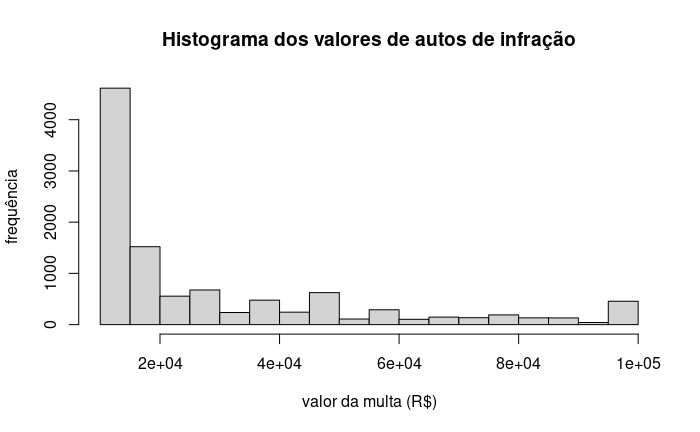

Bigode (diagrama de caixa) dos valores dos autos de infração com valores **entre** R$ 10.000,00 e 100.000,00:

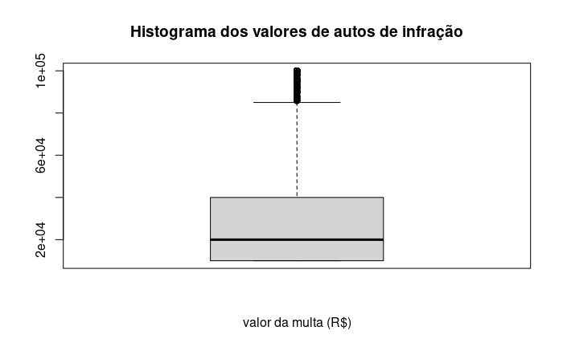

## 9.4 Salvando dados no formato *.RData*

O formato *.RData* é o formato nativo do *R*. Os arquivos *.RData* são arquivos binários, ou seja, não podem ser visualizados em editores de texto ou planilhas (usuais).

Para mostrar como usar as funções save() e load() vamos utilizar os dados dos autos de infreação, lidos anteriormente (no formato *.csv*) e selecionar as colunas de interesse. Depois disso o objeto *ai_df* será armazenado em arquivo binário do R com a extensão .RData.

| ogc_fid | numero_ai | tipo | valor_mult | embargo | cpf_cnpj | data | ano | tipo_infra | nome_uc | the_geom |
| --- | --- | --- | --- | --- | --- | --- | --- | --- | --- | --- |
| 1 | 004TY6C1 | Multa Simples | 33150 | Sim | 39667227553 | 2022-09-20 | 2022 | Das Infrações Relativas à Poluição e outras Infrações Ambientais | PARNA Serra de Itabaiana | MULTIPOINT ((-37.40192777777778 -10.83557777777778)) |
| 2 | 009Z5YHU | Multa Simples | 500 | Não | 30989388115 | 2020-10-13 | 2020 | Das Infrações Cometidas Exclusivamente em Unidades de Conservação | PARNA da Chapada Diamantina | MULTIPOINT ((-41.51638799999999 -12.605834)) |
| 3 | 00EZFFO7 | Multa Simples | 28000 | Não | 72661550291 | 2023-09-25 | 2023 | Das Infrações Contra a Flora | RESEX Chico Mendes | MULTIPOINT ((-69.03551277777778 -10.64926222222222)) |
| 4 | 00GXXMSY | Multa Simples | 445000 | Sim | 18370268234 | 2022-10-05 | 2022 | Das Infrações Contra a Flora | ESEC da Terra do Meio | MULTIPOINT ((-53.96003611111112 -6.29975833333333)) |
| 5 | 00UYJ7IF | Multa Simples | 3520 | Não | 15224135702 | 2022-06-08 | 2022 | Das Infrações Contra a Fauna | RESEX Marinha do Arraial do Cabo | MULTIPOINT ((-42.02027611111111 -22.96546388888889)) |

Agora, salvando e verificando se o arquivo foi criado.

```r
save(ai_df, file = "data/ai_df.RData") # salvando os dados no arquivo
file.exists("data/ai_df.RData") # verificando se arquivo foi salvo no diretório
```

```
[1] TRUE
```

## 9.5 Carregando dados *.RData*

Agora vamos fazer o processo de limpar o ambiente de trabalho do R (liberando memória), e recarregar o dado que gravamos.

```r
# verifica existência de objeto no ambiente de trabalho R
exists("ai_df")
# Verificando se o arquivo existe no computador
file.exists("data/ai_df.RData")
# apagando a variavel ai_df do ambiente de trabalho
rm(ai_df)
# verifica existência do dado no ambiente de trabalho
exists("ai_df") # !deve ocorrer > Error in exists(ai_df): object 'ai_df' not found
# carregando ai_df.RData
load(file = "data/ai_df.RData")
ls()
```

[output not shown]

# 10 REFERÊNCIAS

## 10.1 Pacotes recomendados

### 10.1.1 Análise inferencial

*easyanova* ExpDes.pt

### 10.1.2 Regressão linear

Comandos para Regressão linear *lm* nlme

### 10.1.3 Gráficos

*corrplot -* scatterplot3d *ggplot2 - gramática para construão de gráficos* qgraph *RColorBrewer - criação de palletas de cores

### 10.1.4 Análise multivariada

*biotools* ade4

### 10.1.5 Modelos mistos (REML-BLUP):

*Ime4* pedigreemm *sommer

### 10.1.6 Inferência BVayesiana

*MCMCglmn* rJags *stan

### 10.1.7 Reder neurais artificiais

*RSNNS* neuralnet *Keras

### 10.1.8 Lógica Fuzzy

*FuzzyToolkitUoN

## 10.2 Bases de dados

[Inde, indice de metadados](https://www.inde.gov.br/) [Inde, fauna ameaçada de extinção](https://metadados.inde.gov.br/geonetwork/srv/por/catalog.search;jsessionid=1C21A136D8AF8D2CCCFED5E63BEFD754#/metadata/4eefeb5e-bdd8-4779-82db-ad0dd4ff6e8b) [Inde, Áreas embargadas - ICMBio](https://metadados.inde.gov.br/geonetwork/srv/por/catalog.search;jsessionid=1C21A136D8AF8D2CCCFED5E63BEFD754#/metadata/8eb9a9f4-cf5f-49af-a6e1-498530bddbd3) [Inde, Autos de Infração - ICMBio](https://metadados.inde.gov.br/geonetwork/srv/por/catalog.search;jsessionid=1C21A136D8AF8D2CCCFED5E63BEFD754#/metadata/9dbc4a2e-75c1-4074-a777-3d987ffbf471)

## 10.3 Cursos

DataCamp [Text as Data](https://bookdown.org/davi_moreira/txt4cs/#pref%C3%A1cio) [W3 Schools](https://www.w3schools.com/r/default.asp) ## Sites Revolutions; R-bloggers; KDnuggets.

## 10.4 Referências com sítio internet

Ferreira E, Lisboa W, Introdução ao R - Curso Básico de Linguagem R, Janeiro de 2018, acessado em 01/10/*2024, disponível em https://bookdown.org/wevsena/curso_r_tce/curso_r_tce.html

Adler, J. 2012. R in a Nutshell: A Desktop Quick Reference. O’Reilly Media. https://books.google.com.br/books?id=YK4Qb5x-hoIC.

Cotton, R. 2013. Learning R: A Step-by-Step Function Guide to Data Analysis. O’Reilly Media. https://books.google.com.br/books?id=7dyzAAAAQBAJ.

Gardener, M. 2012. The Essential R Reference. Wiley. https://books.google.com.br/books?id=xvF6hZ0T9ocC.

Teetor, P. 2011a. 25 Recipes for Getting Started with R: Excerpts from the R Cookbook. O’Reilly Media. https://books.google.com.br/books?id=cQy-1yvvq-UC.

———. 2011b. R Cookbook: Proven Recipes for Data Analysis, Statistics, and Graphics. O’Reilly Media. https://books.google.com.br/books?id=KIHuSXyhawEC.

Wickham, H., and G. Grolemund. 2016. R for Data Science: Import, Tidy, Transform, Visualize, and Model Data. O’Reilly Media. https://books.google.com.br/books?id=I6y3DQAAQBAJ.